# Altermap 2026 : perception des maillages territoriaux au Sénégal

Analyse des réponses de 47 étudiants de l’UCAD au questionnaire pilote administré en mai 2026

Auteur·rice

Moumar DIONGUE

Date de publication

2026-05-22

## Introduction

Nous proposons ici un premier dépouillement des réponses au questionnaire-test administré par Moumar Diongué à 47 étudiants de licence 1 de géographie à l’UCAD de Dakar le 21 mai 2026. Les calculs ont été effectués par C. Grasland à l’aide d’un programme R de statistiques et cartographie qui pourra être relancé au fur et à mesure que l’échantillon sera plus étoffé ou sur d’autres échantillons.

# A. QUELQUES QUESTIONS SUR VOUS

La première partie du questionnaire apportait des données de cadrage sur les individus (âge, sexe) et sur l’origine géographique et les trajectoires de mobilité des étudiants.

**Télécharger le jeu de données issues de Kobo Toolbox**

- [Données d’enquête issus de kobo au format label .xlsx](https://github.com/worldregio/altermap/raw/refs/heads/main/data/axe4/ALTERMAP_2026_Gouvernance_Sénégal_V2.xlsx)

On commence par charger les questionnaires issus de Kobo Toolbox en format “label” (texte complet)

## A.1 Sexe

```
           n     %
Un homme  19  40.4
Une femme 28  59.6
Total     47 100.0
```

- **Commentaire** :

## A.2 Âge

```
       n     %
19    11  25.6
20    19  44.2
21     7  16.3
22     3   7.0
23     1   2.3
24     2   4.7
Total 43 100.0
```

- **Commentaire** :

## Nationalité

### A.3.1 Pays de naissance de l’individu

```
         n     %
Sénégal 25  53.2
NA      22  46.8
Total   47 100.0
```

### A.3.2 Pays de naissance de son père

```
         n     %
Mali     1   2.1
Sénégal 24  51.1
NA      22  46.8
Total   47 100.0
```

### A.3.3 Pays de naissance de sa mère

```
         n     %
Mali     1   2.1
Sénégal 25  53.2
NA      21  44.7
Total   47 100.0
```

- **Commentaire** :

## A.4 Département de naissance de l’individu

N.B. 11 étudiants n’ont pas répondu

```
             n     %
Bambey       2   4.3
Bounkiling   1   2.1
Dakar        3   6.4
Diourbel     1   2.1
Fatick       5  10.6
Goudomp      3   6.4
Guinguinéo   1   2.1
Koupentoum   2   4.3
Louga        1   2.1
Matam        2   4.3
Mbacké       1   2.1
Mbour        1   2.1
Pikine       1   2.1
Podor        7  14.9
Rufisque     2   4.3
Sédhiou      1   2.1
Tambacounda  1   2.1
Tivaouane    1   2.1
NA          11  23.4
Total       47 100.0
```

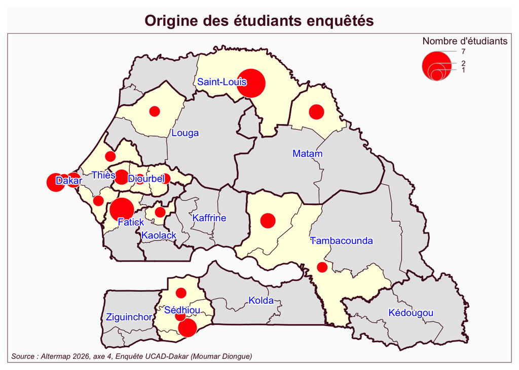

- **Commentaire** :

## A.5 Mobilité interne et trajectoires

### Changement de communes

Réponses à la question des mobilités internes au pays.

```
       n     %
Non    6  12.8
Oui   41  87.2
Total 47 100.0
```

### Trajectoires

On ne traitera pas ici les parcours qui nécessitent un recodage long des réponses. On affiche juste le tableau des trajectoires des étudiants déclarant avoir changé de commune.

Trajectoire des étudiants ayant changé de commune

| id | sex | dep_nais | traj |
| --- | --- | --- | --- |
| L1 | Une femme | Mbacké | Grand yoff,yoff,Touba,Touba Fall |
| L1 001 | Une femme | Koupentoum | Koumpentoum commune |
| L1001 | Une femme | Koupentoum | Koumpentoum |
| L10029 | Une femme | NA | Wouro sidy et Hamady ounaré |
| L10041 | Un homme | NA | Thiès, Dakar |
| L10044 | Une femme | NA | Fatick, Dakar |

- **Commentaire** :

# B. SENTIMENT D’APPARTENANCE TERRITORIALE

## B.1 Echelle d’appartenance

### Echelles citées

On peut tout d’abord examiner quelles échelles ont été les plus mobilisées par les étudiants sans distinguer l’ordre

```
                    n     %
1. Local           40  28.4
2. Arrdt-Dept      23  16.3
3. Région          25  17.7
4. Pays            34  24.1
5. sous-continent   2   1.4
6. continent        9   6.4
7. Monde            4   2.8
8. Autre            4   2.8
Total             141 100.0
```

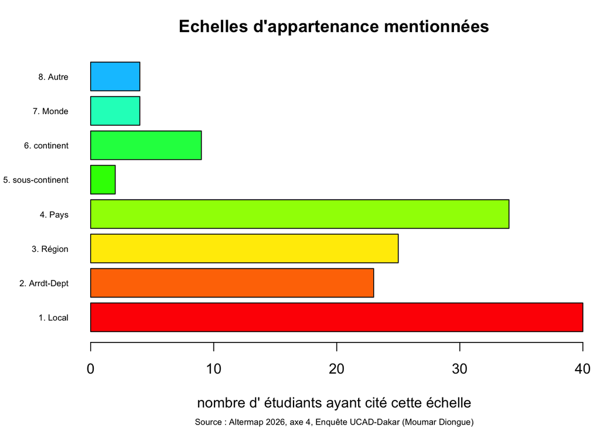

### Echelle citée en premier

On peut ensuite se focaliser sur le premier choix

```
                   n     %
1. Local          29  61.7
2. Arrdt-Dept      2   4.3
3. Région          2   4.3
4. Pays           11  23.4
5. sous-continent  1   2.1
6. continent       1   2.1
7. Monde           1   2.1
Total             47 100.0
```

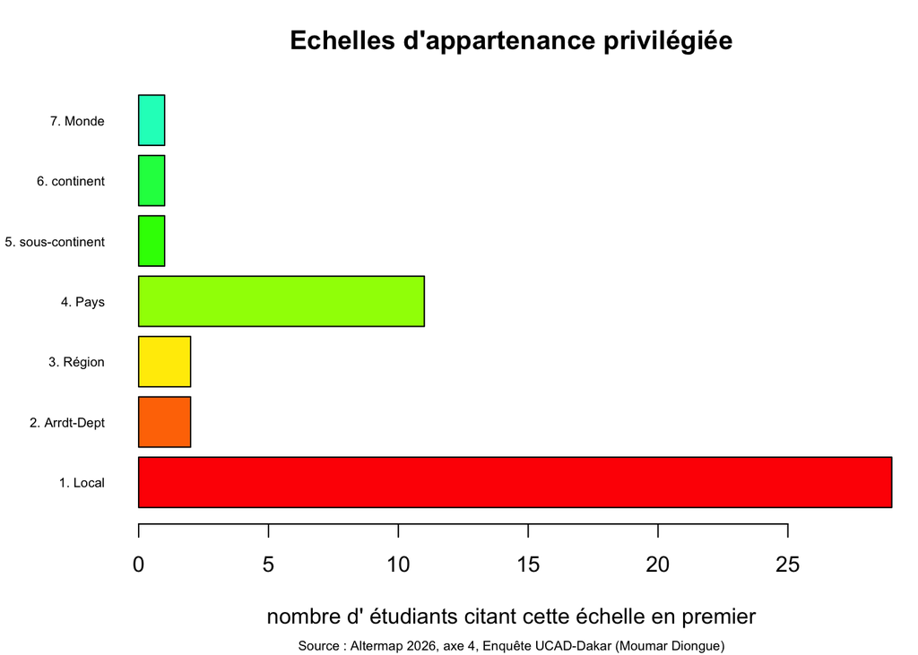

- **Commentaire** :

### Autres échelles

Inventaire des réponses “autres” :

```
             Africain        Arrondissement                Canada
                    1                     1                     1
   Continent africain     Continent Afrique              Diourbel
                    1                     1                     1
               France                 Monde         Pays ( Mali )
                    1                     1                     2
Région administrative               Sédhiou
                    1                     1
```

## B.2 Sentiment d’appartenance à des régions non officielles

Cette question interrogeait les étudiants sur leur sentiment d’apprtenance à des espaces non officiels.

### Nombre de réponses

Plusieursétudiants ont déclaré des appartenances à plusieurs régions.

```
       n     %
1     32  68.1
2      4   8.5
3     11  23.4
Total 47 100.0
```

### Réponses les plus fréquentes

On évalue les régions les plus fréquemment citées.

| region | n | pct |
| --- | --- | --- |
| Casamance | 20 | 27.4 |
| Sine Saloum | 18 | 24.7 |
| Cayor | 16 | 21.9 |
| Baol | 9 | 12.3 |
| Autre | 6 | 8.2 |
| Boundou | 3 | 4.1 |
| Gabu | 1 | 1.4 |

### Autres réponses

On détaille les réponses “*Autre*” qui ont été proposées par certains étudiants :

```
Djolof ,Walo  Fouta  Toro   Fouta toro   Fouta Toro  Saint Louis         Walo
           1            1            1            1            1            1
```

- **Commentaire** :

## B.3 Régions attractives et répulsives

Une manière simple mais efficace de mettre à jour les représentations du Sénégal des étudiants a consisté à leur demander de citer trois régions pays où ils souhaiteraient vivre ou ne pas vivre dans un futur proche. Cela suppose une petite transformation des données pour créer un tableau ou chaque ligne correspond à une réponse sur les pays attractifs ou répulsifs. En d’autres termes les réponses de chaque étudiant correspondront à 6 lignes, 3 pour les régions cités positivement et 3 pour les régions cités négativement.On accompagnera ces réponses des informations que l’on juge utile sur les étudiants afin de pouvoir ensuite faire des regroupements.

A titre d’exemple, voici la forme que prennent les réponses d’un étudiant :

| id | sex | age | dep_nais | ech1 | opi | rnk | NAME_1 |
| --- | --- | --- | --- | --- | --- | --- | --- |
| L1 001 | Une femme | 20 | Koupentoum | 1. Local | neg | 1 | Kolda |
| L1 001 | Une femme | 20 | Koupentoum | 1. Local | neg | 2 | Kaolack |
| L1 001 | Une femme | 20 | Koupentoum | 1. Local | neg | 3 | Tambacounda |
| L1 001 | Une femme | 20 | Koupentoum | 1. Local | pos | 1 | Thiès |
| L1 001 | Une femme | 20 | Koupentoum | 1. Local | pos | 2 | Ziguinchor |
| L1 001 | Une femme | 20 | Koupentoum | 1. Local | pos | 3 | Dakar |

-**Commentaire :** L’étudiante L1 001 est une femme de 20 ans, née dans le département de Koupentoum et déclare en premier le niveau local d’appartenance. Elle déclare qu’elle ne souhaiterait pas vivre dans les régions de Kolda, Kaolack et Tambacounda. Mais elle aimerait vivre dans les régions de Thiès, Ziguinchor ou Dakar.

### Régions attractives

Si on ne tient pas compte du rang des régions cités positivement, on peut établir un tableau de fréquence indiquant le nombre de fois ou une région a été cité positivement par l’un des étudiants de notre échantillon.

Régions les plus attractives pour les étudiants

| Rang | Nom | Nb. réponses | % étudiants |
| --- | --- | --- | --- |
| 1 | Saint-Louis | 38 | 80.9 |
| 2 | Dakar | 36 | 76.6 |
| 3 | Ziguinchor | 19 | 40.4 |
| 4 | Thiès | 14 | 29.8 |
| 5 | Sédhiou | 7 | 14.9 |
| 6 | Diourbel | 5 | 10.6 |
| 6 | Matam | 5 | 10.6 |
| 8 | Kédougou | 4 | 8.5 |
| 8 | Louga | 4 | 8.5 |
| 10 | Kaolack | 3 | 6.4 |
| 10 | Kolda | 3 | 6.4 |
| 12 | Fatick | 2 | 4.3 |
| 13 | Tambacounda | 1 | 2.1 |

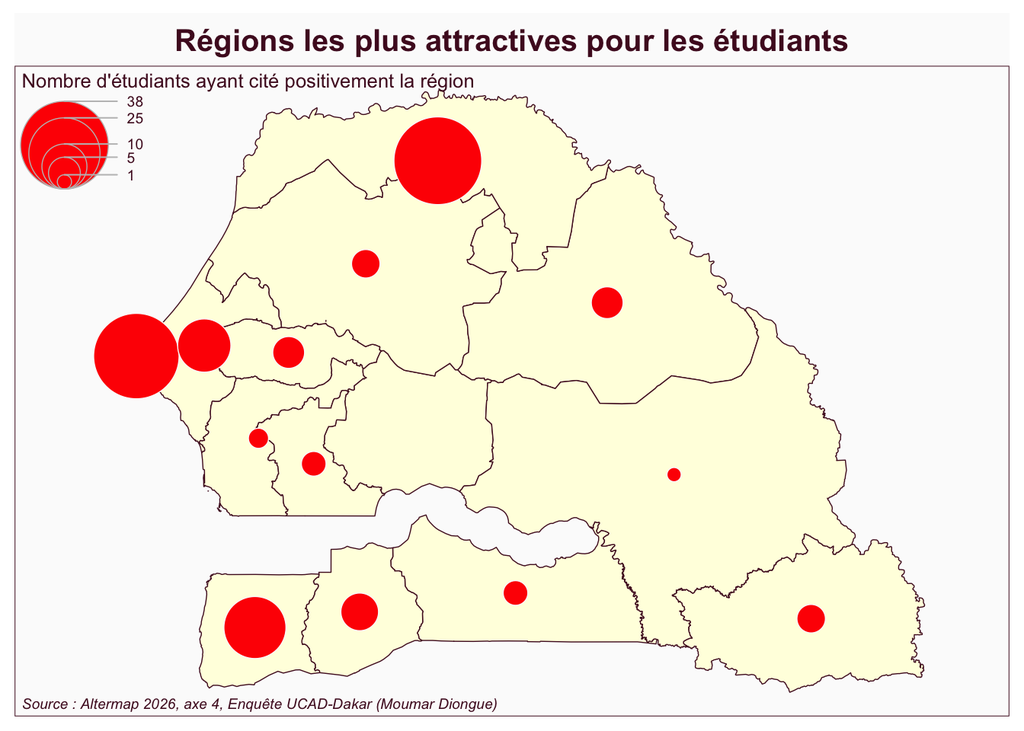

- **Commentaire** :

### Régions répulsives

Régions les plus répulsives pour les étudiants

| Rang | Nom | Nb. réponses | % étudiants |
| --- | --- | --- | --- |
| 1 | Tambacounda | 28 | 59.6 |
| 2 | Matam | 20 | 42.6 |
| 3 | Kaffrine | 15 | 31.9 |
| 4 | Kolda | 14 | 29.8 |
| 4 | Kédougou | 14 | 29.8 |
| 6 | Kaolack | 11 | 23.4 |
| 7 | Fatick | 10 | 21.3 |
| 8 | Sédhiou | 9 | 19.1 |
| 9 | Louga | 8 | 17.0 |
| 10 | Diourbel | 5 | 10.6 |
| 10 | Ziguinchor | 5 | 10.6 |
| 12 | Dakar | 1 | 2.1 |
| 12 | Thiès | 1 | 2.1 |

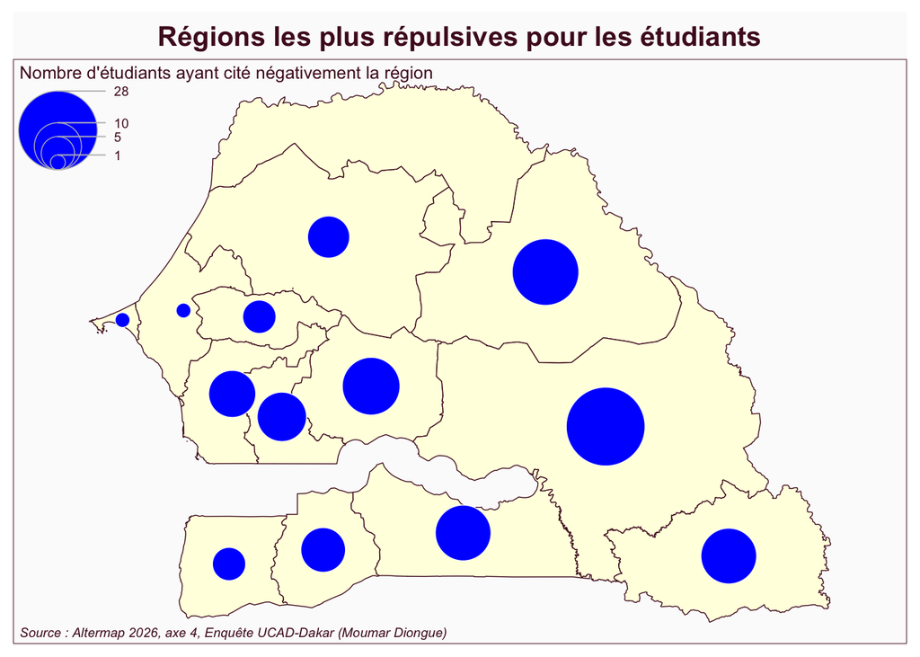

- **Commentaire** :

### Synthèse

L’appréciation que les étudiants donnent d’une région doit être envisagé selon deux dimensions complémentaires, la saillance et l’opinion

- **la saillance** (en anglais *salience*) est le fait qu’une régionse présente à l’esprit dun étudiant lorsqu’on lui demande de porter un jugement. Peu importe que le jugement soit positif ou négatif, si une région est citée par l’étudiant c’est qu’il possède des informations sur elle, qu’il en a reçu et à choisi de les retenir. Bref, la saillance manifeste une reconnaissance de l’existence d’une région et signale sa présence dans la carte mentale de la personne. On la définira donc comme le % des étudiants qui ont cité une région, positivement ou négativement, peu importe, et on la mesurera sur une échelle de 0 (jamais citée) à 100 (toujours citée) :

$Saillance_i = 100\times \frac{Pos_i + Neg_i}{n}$

$Polarisation_i = \frac{Pos_i-Neg_i}{Pos_i+Neg_i}$

### Tableau de synthèse

Saillance et attractivité des régions du Sénégal

| Nom | Négatif | Positif | Total | Saillance (%) | Polarisation |
| --- | --- | --- | --- | --- | --- |
| Saint-Louis | 0 | 38 | 38 | 80.9 | 1.00 |
| Dakar | 1 | 36 | 37 | 78.7 | 0.95 |
| Tambacounda | 28 | 1 | 29 | 61.7 | -0.93 |
| Matam | 20 | 5 | 25 | 53.2 | -0.60 |
| Ziguinchor | 5 | 19 | 24 | 51.1 | 0.58 |
| Kédougou | 14 | 4 | 18 | 38.3 | -0.56 |
| Kolda | 14 | 3 | 17 | 36.2 | -0.65 |
| Sédhiou | 9 | 7 | 16 | 34.0 | -0.12 |
| Kaffrine | 15 | 0 | 15 | 31.9 | -1.00 |
| Thiès | 1 | 14 | 15 | 31.9 | 0.87 |
| Kaolack | 11 | 3 | 14 | 29.8 | -0.57 |
| Fatick | 10 | 2 | 12 | 25.5 | -0.67 |
| Louga | 8 | 4 | 12 | 25.5 | -0.33 |
| Diourbel | 5 | 5 | 10 | 21.3 | 0.00 |

### Graphique de synthèse

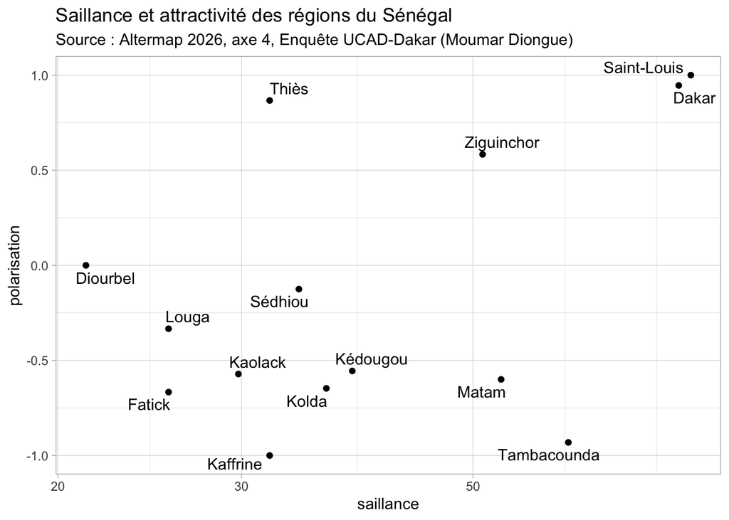

### Cartogramme

On déforme la surface des régions pour leur donner une superficie prportionnelle à leur saillance, c’est-à-dire au nombre de fois où ils ont été cités. Puis on les colorie en fonction de la valeur de l’indice de polarisation , de rouge foncé pour les régions les plus répulsives à bleu foncé pour les plus attractives, en passant par jaune clair pour les régions neutres qui ont autant d’avis positis que négatifs.

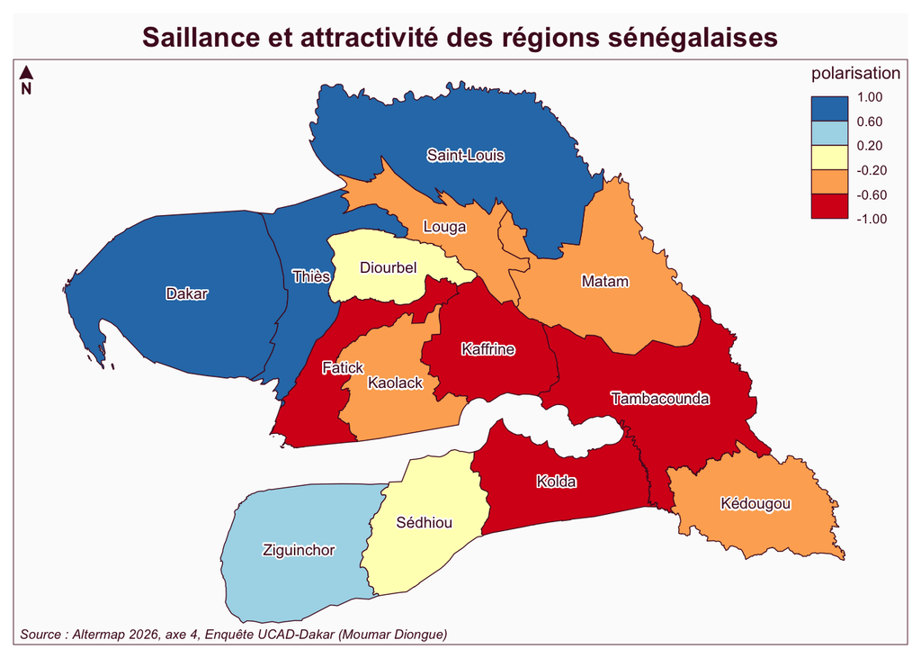

- **Commentaire** :

## B.4 Royaume et entités historiques précoloniales

### Connaissance

```
       n     %
Non   26  55.3
Oui   21  44.7
Total 47 100.0
```

### Nom

```
                                   n     %
Baol                               2   9.5
Boal                               1   4.8
Casamance                          1   4.8
Cayor                              2   9.5
Fouta Toro                         4  19.0
Gaabou                             1   4.8
La casamance                       1   4.8
Le Royaume de Kasa                 1   4.8
Royaume du kasa                    1   4.8
Royaume du RIP de Maba DIAKHOU Ba  1   4.8
Royaume du sine                    1   4.8
Sine                               2   9.5
Sine saloum                        2   9.5
Walo                               1   4.8
Total                             21 100.0
```

- **Commentaire** :

## B.5 Mots associés aux royaumes

On ne retient que les 20 mots les plus fréquents cités au moins trois fois pour construire les nuages de mots ci-dessous.

N.B. Il faudra procéder à un recodage manuel pour regrouper les variantes d’un même mot.

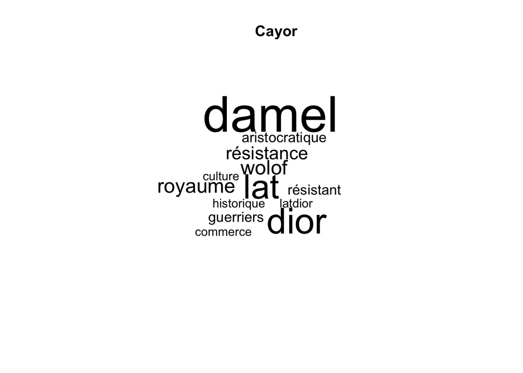

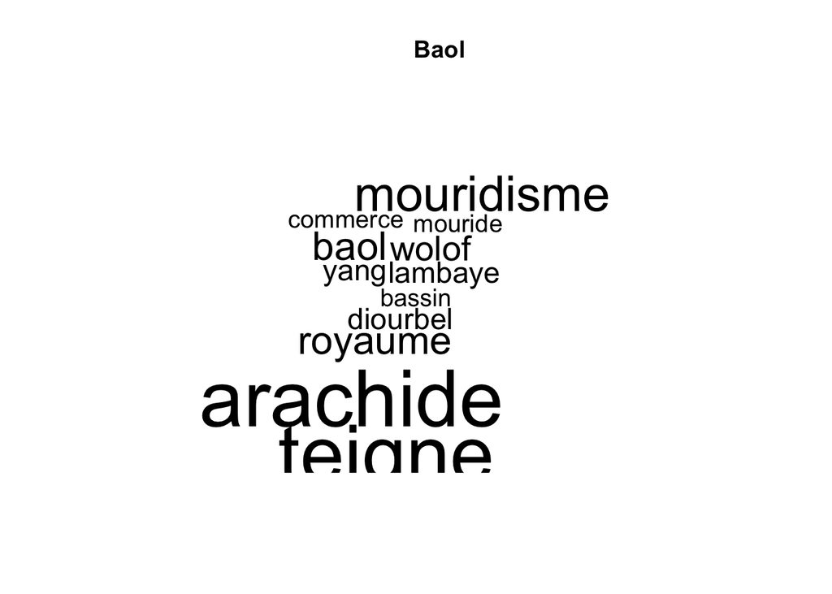

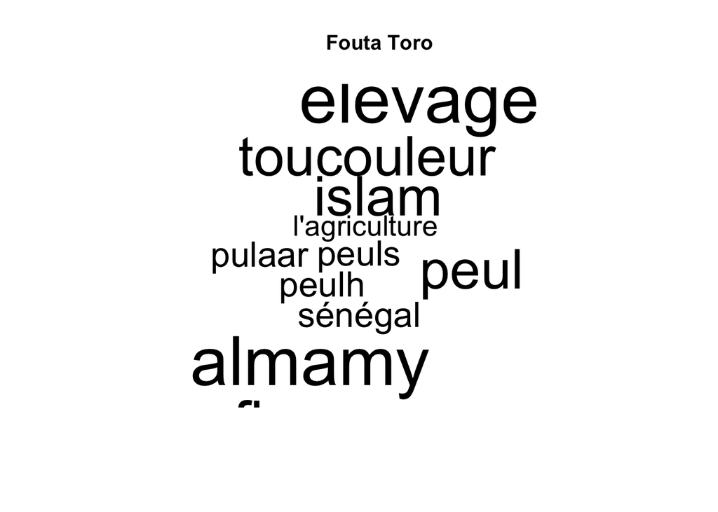

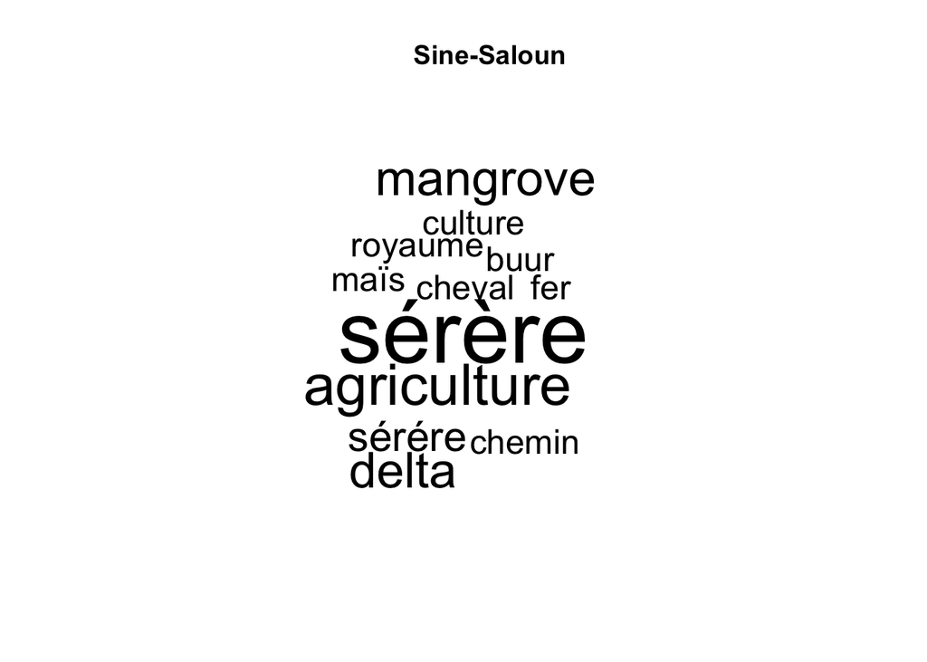

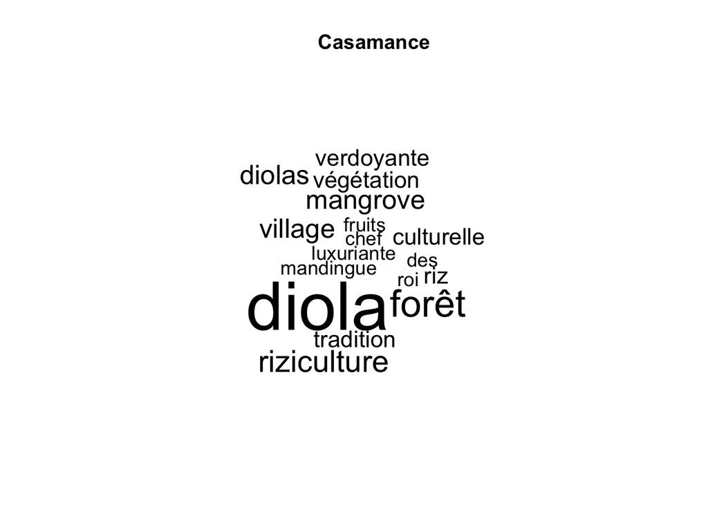

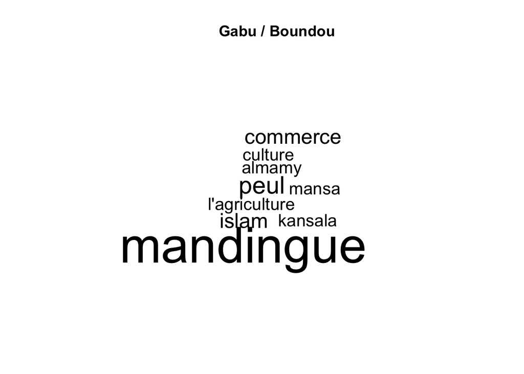

- **Commentaire** :